# Intervalos de confianza y pruebas de hipótesis en R

Tomemos unos datos disponibles en R y aprendamos a implementar las procedimientos básicos de inferencia estadística.

## Paquetes necesarios

```r
library(openintro)
library(RcmdrMisc)
library(ggplot2)

# Tema blanco en ggplot2
theme_set(theme_bw())
```

## Exploremos los datos

Consideremos los datos de la encuesta del *National Center of Education Statistics.* (EUA).

```r
# Resumen de los datos
str(hsb2)
```

```
tibble [200 x 11] (S3: tbl_df/tbl/data.frame)
 $ id     : int [1:200] 70 121 86 141 172 113 50 11 84 48 ...
 $ gender : chr [1:200] "male" "female" "male" "male" ...
 $ race   : chr [1:200] "white" "white" "white" "white" ...
 $ ses    : Factor w/ 3 levels "low","middle",..: 1 2 3 3 2 2 2 2 2 2 ...
 $ schtyp : Factor w/ 2 levels "public","private": 1 1 1 1 1 1 1 1 1 1 ...
 $ prog   : Factor w/ 3 levels "general","academic",..: 1 3 1 3 2 2 1 2 1 2 ...
 $ read   : int [1:200] 57 68 44 63 47 44 50 34 63 57 ...
 $ write  : int [1:200] 52 59 33 44 52 52 59 46 57 55 ...
 $ math   : int [1:200] 41 53 54 47 57 51 42 45 54 52 ...
 $ science: int [1:200] 47 63 58 53 53 63 53 39 58 50 ...
 $ socst  : int [1:200] 57 61 31 56 61 61 61 36 51 51 ...
```

Exploremos algunas de las variables:

```r
with(hsb2, levels(factor(race)))
```

```
[1] "african american" "asian"            "hispanic"         "white"
```

```r
with(hsb2, levels(prog))
```

```
[1] "general"    "academic"   "vocational"
```

Exploremos el desempeño en matemáticas.

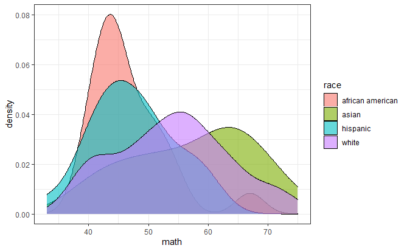

```r
ggplot(data=hsb2, mapping=aes(x=math)) + geom_density(aes(fill=race),
                                                      alpha=0.6)
```

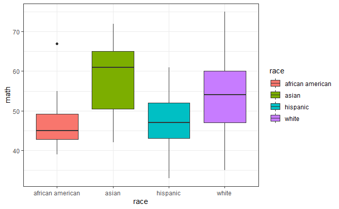

```r
ggplot(data=hsb2, mapping=aes(y=math, x=race)) +
  geom_boxplot(aes(fill=race))
```

### Estadísticos descriptivos

```r
numSummary(hsb2[,"math", drop=FALSE], groups=hsb2$race,
  statistics=c("mean", "sd", "IQR", "quantiles", "cv"), quantiles=c(0,.25,.5,
  .75,1))
```

```
                     mean        sd  IQR        cv 0%   25% 50%   75% 100%
african american 46.75000  6.487843  6.5 0.1387774 39 42.75  45 49.25   67
asian            57.27273 10.120187 14.5 0.1767017 42 50.50  61 65.00   72
hispanic         47.41667  6.983936  9.0 0.1472886 33 43.00  47 52.00   61
white            53.97241  9.383011 13.0 0.1738483 35 47.00  54 60.00   75
                 math:n
african american     20
asian                11
hispanic             24
white               145
```

## Notación

Hagamos inferencia sobre los parámetros de las poblaciones que confluyen en estos datos. Sea $\theta_{j}^i$ el puntaje promedio e el área $i$ para el grupo $j$, donde:

- $\theta$ es cualquiera de los parámetros que hemos estudiado: $\mu, \sigma, p$
- $i=\lbrace\text{r, w, s, m, ss}\rbrace$, que corresponde a `read, write, science, math, socst` respectivamente.
- $j=\lbrace\text{aa, a, h, w}\rbrace$, que corresponde a `african american, asian, hispanic, white`.

# Inferencia sobre una población

Consideremos la muestra de los hispanos:

```r
hispanic <- hsb2[hsb2$race=='hispanic',]
hispanic
```

| id | gender | race | ses | schtyp | prog | read | write | math | science | socst |
| --- | --- | --- | --- | --- | --- | --- | --- | --- | --- | --- |
| 11 | male | hispanic | middle | public | academic | 34 | 46 | 45 | 39 | 36 |
| 20 | male | hispanic | high | public | academic | 60 | 52 | 57 | 61 | 61 |
| 12 | male | hispanic | middle | public | vocational | 37 | 44 | 45 | 39 | 46 |
| 16 | male | hispanic | low | public | vocational | 47 | 31 | 44 | 36 | 36 |
| 7 | male | hispanic | middle | public | academic | 57 | 54 | 59 | 47 | 51 |
| 21 | male | hispanic | middle | public | general | 44 | 44 | 61 | 50 | 46 |
| 15 | male | hispanic | high | public | vocational | 39 | 39 | 44 | 26 | 42 |
| 22 | male | hispanic | middle | public | vocational | 42 | 39 | 39 | 56 | 46 |
| 9 | male | hispanic | middle | public | vocational | 48 | 49 | 52 | 44 | 51 |
| 18 | male | hispanic | middle | public | vocational | 50 | 33 | 49 | 44 | 36 |

[output cut: 14 more lines]

## Puntaje promedio para los hispanos en matemáticas

Ya vimos que el promedio muestral tiene como resltado un valor de 47.42. ¿Existe evidencia para afirmar que el puntaje promedio de los hispanos en matemáticas es 50? Usemos un nivel de confianza de 94%.

```r
t.test(hispanic$math, conf.level = 0.94)
```

```
    One Sample t-test

data:  hispanic$math
t = 33.261, df = 23, p-value < 2.2e-16
alternative hypothesis: true mean is not equal to 0
94 percent confidence interval:
 44.59649 50.23684
sample estimates:
mean of x
 47.41667
```

## Proporción de personas que aprobaron

Suponga que el puntaje de corte para aprobar las pruebas es de 50. ¿Es válido afirmar que el 30% de los hombres aprueban en matemáticas?

Vamos a identificar los éxitos.

```r
male <- hsb2[hsb2$gender=='male',]
sucess1 <- male$math > 50
sucess1
```

```
 [1] FALSE  TRUE FALSE  TRUE  TRUE FALSE FALSE  TRUE  TRUE  TRUE  TRUE  TRUE
[13]  TRUE FALSE FALSE  TRUE  TRUE  TRUE  TRUE FALSE  TRUE FALSE  TRUE FALSE
[25] FALSE  TRUE  TRUE FALSE FALSE  TRUE  TRUE  TRUE  TRUE FALSE  TRUE  TRUE
[37]  TRUE FALSE FALSE FALSE  TRUE  TRUE FALSE FALSE  TRUE FALSE  TRUE  TRUE
[49]  TRUE  TRUE FALSE  TRUE FALSE  TRUE FALSE FALSE FALSE  TRUE  TRUE FALSE
[61]  TRUE FALSE FALSE FALSE FALSE  TRUE FALSE  TRUE FALSE FALSE  TRUE  TRUE
[73]  TRUE FALSE FALSE  TRUE  TRUE FALSE  TRUE  TRUE  TRUE  TRUE FALSE FALSE
[85]  TRUE  TRUE FALSE FALSE  TRUE  TRUE FALSE
```

Ahora, vamos a contarlos.

```r
# Número de éxitos
x1 <- sum(sucess1)
x1
```

```
[1] 51
```

Además, sabemos que $n=91$. Entonces, usando un nivel de confianza de 93%:

```r
prop.test(x=x1, n=nrow(male), conf.level=0.93)
```

```
    1-sample proportions test with continuity correction

data:  x1 out of nrow(male), null probability 0.5
X-squared = 1.0989, df = 1, p-value = 0.2945
alternative hypothesis: true p is not equal to 0.5
93 percent confidence interval:
 0.4602753 0.6561537
sample estimates:
        p
0.5604396
```

# Comparaciones (Inferencia sobre dos poblaciones)

Ahora, también consideremos la muestra de los afroamericanos.

```r
africanam <- hsb2[hsb2$race=='african american',]
africanam
```

| id | gender | race | ses | schtyp | prog | read | write | math | science | socst |
| --- | --- | --- | --- | --- | --- | --- | --- | --- | --- | --- |
| 50 | male | african american | middle | public | general | 50 | 59 | 42 | 53 | 61 |
| 48 | male | african american | middle | public | academic | 57 | 55 | 52 | 50 | 51 |
| 38 | male | african american | low | public | academic | 45 | 57 | 50 | 31 | 56 |
| 41 | male | african american | middle | public | academic | 50 | 40 | 45 | 55 | 56 |
| 53 | male | african american | middle | public | vocational | 34 | 37 | 46 | 39 | 31 |
| 40 | male | african american | low | public | general | 42 | 41 | 43 | 50 | 41 |
| 49 | male | african american | high | public | vocational | 50 | 40 | 39 | 49 | 47 |
| 47 | female | african american | low | public | academic | 47 | 46 | 49 | 33 | 41 |
| 54 | female | african american | low | private | general | 47 | 54 | 46 | 50 | 56 |
| 37 | female | african american | low | public | vocational | 41 | 47 | 40 | 39 | 51 |

[output cut: 10 more lines]

## Cociente de Varianzas

Como pudimos ver en la exploración de datos, $S_h^{(m)}=6.98$ y $S_{aa}^{(m)}=6.49$. ¿Tienen realmente la misma dispersión?

```r
var.test(hispanic$math, africanam$math)
```

```
    F test to compare two variances

data:  hispanic$math and africanam$math
F = 1.1588, num df = 23, denom df = 19, p-value = 0.7511
alternative hypothesis: true ratio of variances is not equal to 1
95 percent confidence interval:
 0.4701324 2.7514766
sample estimates:
ratio of variances
          1.158777
```

Entonces, $\sigma_h^{2(m)} / \sigma_{aa}^{2(m)} \in (0.47,2.75)$.

## Diferencia de medias

Recordemos que $\bar{X}_h^m=47.42$ y $\bar{X}_a^m=46.75$. ¿Es realmente diferente el puntaje promedio de ambos grupos? Usemos un 95% de confianza.

```r
t.test(hispanic$math, africanam$math, conf.level=0.95,
       var.equal=TRUE)
```

```
    Two Sample t-test

data:  hispanic$math and africanam$math
t = 0.32554, df = 42, p-value = 0.7464
alternative hypothesis: true difference in means is not equal to 0
95 percent confidence interval:
 -3.466181  4.799515
sample estimates:
mean of x mean of y
 47.41667  46.75000
```

## Diferencia de proporciones

Ahora, determinemos si hay diferencia en la proporción de personas que aprobaron según el género.

```r
female <- hsb2[hsb2$gender=='female',]
success2 <- female$math > 50
success2
```

```
  [1]  TRUE  TRUE  TRUE FALSE  TRUE  TRUE  TRUE FALSE  TRUE  TRUE  TRUE FALSE
 [13]  TRUE  TRUE  TRUE  TRUE FALSE FALSE  TRUE FALSE FALSE  TRUE  TRUE  TRUE
 [25] FALSE  TRUE  TRUE  TRUE FALSE FALSE FALSE  TRUE  TRUE FALSE  TRUE FALSE
 [37]  TRUE  TRUE FALSE  TRUE  TRUE  TRUE FALSE FALSE  TRUE  TRUE  TRUE FALSE
 [49] FALSE FALSE FALSE  TRUE FALSE  TRUE FALSE FALSE FALSE FALSE FALSE FALSE
 [61]  TRUE FALSE FALSE  TRUE  TRUE FALSE  TRUE FALSE  TRUE  TRUE FALSE  TRUE
 [73]  TRUE FALSE FALSE  TRUE FALSE  TRUE  TRUE FALSE FALSE FALSE  TRUE FALSE
 [85]  TRUE  TRUE  TRUE FALSE  TRUE FALSE FALSE  TRUE  TRUE  TRUE  TRUE  TRUE
 [97] FALSE  TRUE  TRUE FALSE FALSE  TRUE FALSE  TRUE  TRUE FALSE  TRUE  TRUE
[109]  TRUE
```

```r
x2 <- sum(success2)
x2
```

```
[1] 62
```

y ahora podemos aplicar una prueba para la diferencia de proporciones.

```r
nm <- nrow(male)
nf <- nrow(female)
prop.test(x=c(x1, x2), n=c(nm, nf))
```

```
    2-sample test for equality of proportions with continuity correction

data:  c(x1, x2) out of c(nm, nf)
X-squared = 4.6793e-30, df = 1, p-value = 1
alternative hypothesis: two.sided
95 percent confidence interval:
 -0.1547322  0.1379967
sample estimates:
   prop 1    prop 2
0.5604396 0.5688073
```